# Reproducible Research: Peer Assessment 1 (Elisa Du)

Load some packages.

```r
library(knitr)
library(dplyr)
```

```r
library(ggplot2)
```

First, set global options.

```r
opts_chunk$set(echo=TRUE,cache=FALSE)
```

## Loading and preprocessing the data

```r
df<-read.csv('activity.csv',sep=',',na.strings = 'NA')
head(df)
```

```
##   steps       date interval
## 1    NA 2012-10-01        0
## 2    NA 2012-10-01        5
## 3    NA 2012-10-01       10
## 4    NA 2012-10-01       15
## 5    NA 2012-10-01       20
## 6    NA 2012-10-01       25
```

## What is mean total number of steps taken per day?

To make a histogram of total number of steps taken each day, first sort data by date.

```r
df2<-df[!is.na(df$steps),] # subset all rows with non-NA values
head(df2)
```

```
##     steps       date interval
## 289     0 2012-10-02        0
## 290     0 2012-10-02        5
## 291     0 2012-10-02       10
## 292     0 2012-10-02       15
## 293     0 2012-10-02       20
## 294     0 2012-10-02       25
```

```r
df_GroupByDate<-group_by(df2,date) # group by 'date' as factor
head(df_GroupByDate)
```

```
## # A tibble: 6 x 3
## # Groups:   date [1]
##   steps date       interval
##   <int> <fct>         <int>
## 1     0 2012-10-02        0
## 2     0 2012-10-02        5
## 3     0 2012-10-02       10
## 4     0 2012-10-02       15
## 5     0 2012-10-02       20
## 6     0 2012-10-02       25
```

```r
df_stepsPerDay<-summarise(df_GroupByDate,TotalSteps=sum(steps)) # create new data frame
head(df_stepsPerDay)
```

```
## # A tibble: 6 x 2
##   date       TotalSteps
##   <fct>           <int>
## 1 2012-10-02        126
## 2 2012-10-03      11352
## 3 2012-10-04      12116
## 4 2012-10-05      13294
## 5 2012-10-06      15420
## 6 2012-10-07      11015
```

Now we can plot the histogram.

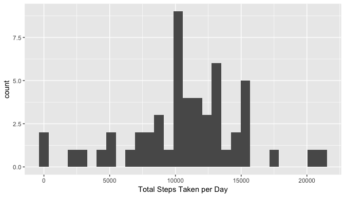

```r
plot1<-qplot(TotalSteps,data=df_stepsPerDay,geom='histogram')
plot1+labs(x='Total Steps Taken per Day')
```

Now we find the mean total number of steps taken for each day.

```r
meanTotalSteps<- mean(df_stepsPerDay$TotalSteps)
meanTotalSteps
```

```
## [1] 10766.19
```

```r
meanTotalSteps<-as.numeric(format(meanTotalSteps,digits=5))
meanTotalSteps # round to integer
```

```
## [1] 10766
```

Next we find the median total number of steps taken for each day.

```r
medianTotalSteps<- median(df_stepsPerDay$TotalSteps)
meanTotalSteps<-as.numeric(format(medianTotalSteps,digits=5))
medianTotalSteps # round to integer
```

```
## [1] 10765
```

The mean total number of steps taken per day is 10766 (rounded to integer).  
The median total number of steps taken per day is 10765.

## What is the average daily activity pattern?

To plot the average number of steps per 5-minute interval:

```r
df_GroupByInterval<-group_by(df2,interval)
tail(df_GroupByInterval)
```

```
## # A tibble: 6 x 3
## # Groups:   interval [6]
##   steps date       interval
##   <int> <fct>         <int>
## 1     0 2012-11-29     2330
## 2     0 2012-11-29     2335
## 3     0 2012-11-29     2340
## 4     0 2012-11-29     2345
## 5     0 2012-11-29     2350
## 6     0 2012-11-29     2355
```

```r
df_AveStepsInterval <- summarise(df_GroupByInterval,MeanSteps = mean(steps))
head(df_AveStepsInterval)
```

```
## # A tibble: 6 x 2
##   interval MeanSteps
##      <int>     <dbl>
## 1        0    1.72
## 2        5    0.340
## 3       10    0.132
## 4       15    0.151
## 5       20    0.0755
## 6       25    2.09
```

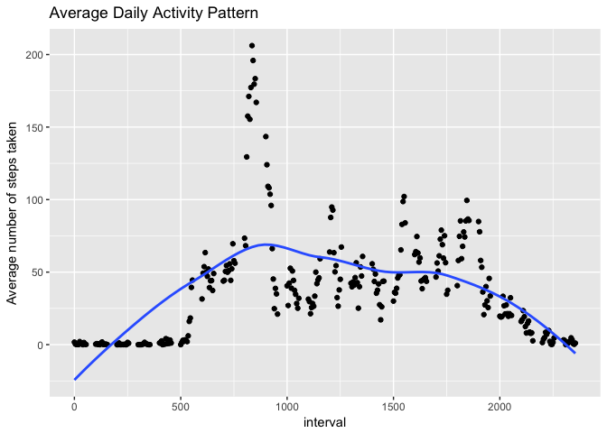

```r
plot2<-qplot(interval,MeanSteps,data=df_AveStepsInterval,geom='point')
plot2 + geom_smooth(se=FALSE) + labs(x='interval',y='Average number of steps taken',
        title='Average Daily Activity Pattern')
```

To find the 5-minute interval where the average number of steps taken is at a maximum:

```r
max <- max(df_AveStepsInterval$MeanSteps)
# interval at which max avg steps occur
maxInt<-df_AveStepsInterval[df_AveStepsInterval$MeanSteps==max,]$interval
maxInt
```

```
## [1] 835
```

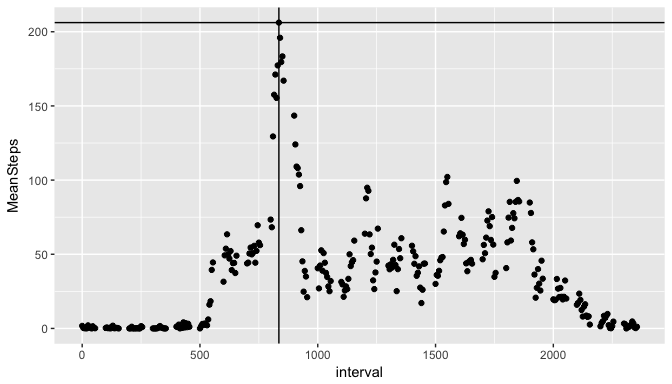

```r
# plot where max average step occurs
plot2 + geom_hline(yintercept = max) + geom_vline(xintercept = maxInt)
```

Therefore the interval 835 contains the maximum average number of steps.

## Imputing missing values

```r
df_NA<-df[is.na(df$steps),]
nrow(df_NA)
```

```
## [1] 2304
```

There are 2304 missing values in the dataset.

Next, fill in all missing values as mean of the corresponding 5-min interval.

‘impdata’ is the new dataset with the missing values filled in.

```r
impData<-cbind(df,MeanSteps=df_AveStepsInterval$MeanSteps)
impData$steps[is.na(impData$steps)] <- impData[is.na(impData$steps),]$MeanSteps
head(impData)
```

```
##       steps       date interval MeanSteps
## 1 1.7169811 2012-10-01        0 1.7169811
## 2 0.3396226 2012-10-01        5 0.3396226
## 3 0.1320755 2012-10-01       10 0.1320755
## 4 0.1509434 2012-10-01       15 0.1509434
## 5 0.0754717 2012-10-01       20 0.0754717
## 6 2.0943396 2012-10-01       25 2.0943396
```

Plot histogram of total number of steps taken each day, accounting for filled-in missing values.

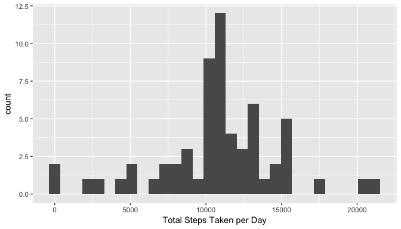

```r
Newdf_GroupByDate<-group_by(impData,date) # group by 'date' as factor
Newdf_stepsPerDay<-summarise(Newdf_GroupByDate,TotalSteps=sum(steps)) # create new data frame
plot3<-qplot(TotalSteps,data=Newdf_stepsPerDay,geom='histogram')
plot3+labs(x='Total Steps Taken per Day')
```

Find new mean and median.

```r
NewMeanTot<- mean(Newdf_stepsPerDay$TotalSteps)
NewMeanTot<-as.numeric(format(meanTotalSteps,digits=5))
NewMeanTot # round to integer
```

```
## [1] 10765
```

```r
NewMedTot<- median(Newdf_stepsPerDay$TotalSteps)
NewMedTot<-as.numeric(format(meanTotalSteps,digits=5))
NewMedTot
```

```
## [1] 10765
```

## Are there differences in activity patterns between weekdays and weekends?

Create new factor variable comprised of the levels ‘weekday’ and ‘weekend’. Incorporate into dataset with filled-in missing vlaues to differentiate date as weekday or weekend.

```r
impData$date<-as.Date(impData$date)
WeekDays<-c('Monday','Tuesday','Wednesday','Thursday','Friday')
impData$DayType<-factor((weekdays(impData$date) %in% WeekDays), levels=c(FALSE,TRUE),labels=c('weekend','weekDay'))
df_WeekDay <- impData[impData$DayType == 'weekDay', ]
df_Weekend<- impData[impData$DayType == 'weekend', ]
```

We can now plot the average steps taken for both weekends and weekdays.

```r
df_WeekDayInt<-group_by(df_WeekDay,interval)
head (df_WeekDayInt)
```

```
## # A tibble: 6 x 5
## # Groups:   interval [6]
##    steps date       interval MeanSteps DayType
##    <dbl> <date>        <int>     <dbl> <fct>
## 1 1.72   2012-10-01        0    1.72   weekDay
## 2 0.340  2012-10-01        5    0.340  weekDay
## 3 0.132  2012-10-01       10    0.132  weekDay
## 4 0.151  2012-10-01       15    0.151  weekDay
## 5 0.0755 2012-10-01       20    0.0755 weekDay
## 6 2.09   2012-10-01       25    2.09   weekDay
```

```r
df_WeekdayAve <- summarise(df_WeekDayInt,MeanSteps = mean(steps))
head(df_WeekdayAve)
```

```
## # A tibble: 6 x 2
##   interval MeanSteps
##      <int>     <dbl>
## 1        0    2.25
## 2        5    0.445
## 3       10    0.173
## 4       15    0.198
## 5       20    0.0990
## 6       25    1.59
```

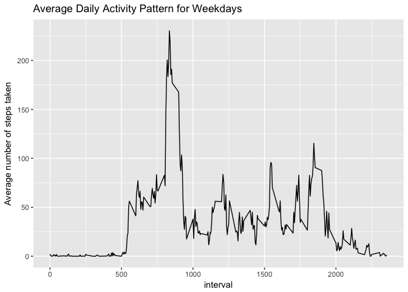

```r
plot4 <- qplot(interval,MeanSteps,data=df_WeekdayAve,geom = 'line' )
plot4 + labs(x='interval',y='Average number of steps taken',
             title='Average Daily Activity Pattern for Weekdays')
```

```r
df_WeekEndInt <- group_by(df_Weekend,interval)
tail(df_WeekEndInt)
```

```
## # A tibble: 6 x 5
## # Groups:   interval [6]
##   steps date       interval MeanSteps DayType
##   <dbl> <date>        <int>     <dbl> <fct>
## 1    17 2012-11-25     2330     2.60  weekend
## 2   176 2012-11-25     2335     4.70  weekend
## 3    94 2012-11-25     2340     3.30  weekend
## 4    26 2012-11-25     2345     0.642 weekend
## 5     0 2012-11-25     2350     0.226 weekend
## 6     0 2012-11-25     2355     1.08  weekend
```

```r
df_WeekendAve <- summarise(df_WeekEndInt,MeanSteps = mean(steps))
head(df_WeekendAve)
```

```
## # A tibble: 6 x 2
##   interval MeanSteps
##      <int>     <dbl>
## 1        0   0.215
## 2        5   0.0425
## 3       10   0.0165
## 4       15   0.0189
## 5       20   0.00943
## 6       25   3.51
```

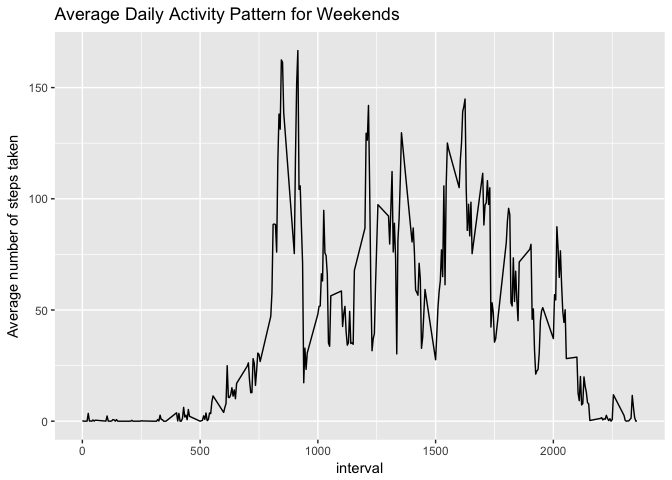

```r
plot5 <- qplot(interval,MeanSteps,data=df_WeekendAve,geom = 'line' )
plot5 + labs(x='interval',y='Average number of steps taken',
             title='Average Daily Activity Pattern for Weekends')
```